# Comparison

Kacper Kaszuba

2024-10-09

# Introduction

The results below shows the comparison of several normalization and imputation methods. We decided to use 4 imputation methods:

1. Shifted Distribution based on the data;
2. Imputation using the Random Forest algorithm;
3. Imputation using the k-Nearest Neighbors algorithm;
4. Imputation using the ludovic method.

1. Z-Score Normalization
2. Min-Max Normalization
3. Median Scaling
4. MAD (Median Absolute Deviation) Scaling
5. Linear Regression Normalization
6. VSN (Variance Stabilization Normalization)
7. EigenMS

We used the following parameters for the K-Nearest Neighbors algorithm (bold row):

| k | RMSE | Rsquared | MAE |
| --- | --- | --- | --- |
| **5** | **560141411** | **0.5764903** | **83499878** |
| 7 | 586141572 | 0.5110148 | 89345187 |
| 9 | 615649021 | 0.4549313 | 93976048 |

For the Random Forest algorithm we used the Grid Search method to find the best hyperparameters. The table belows shows the output of the top 10 models.

**GRID SEARCH FOR RANDOM FOREST MODEL**

[output not shown]

Base on the output of the grid search, we can see that there is better model than default and it is random forest model with the following hyperparameters:

- num.trees = 100
- mtry = 4
- min.node.size = 5
- replace = FALSE
- sample.fraction = 0.80

We train Linear Regression Model which, after the stepwise selection, has the following formula:

$$LFQvalue = 8631815 \cdot no.proteins
-18172773 \cdot peptides + 1794237 \cdot
seq.coverage +\\ + 807933 \cdot mol.weight.kDa + 430143 \cdot score +
1490175 \cdot ms.count$$

Where:

- `no.proteins` - Number of proteins contained within the group.
- `peptides` - The total number of peptide sequences associated with the protein group (i.e. for all the proteins in the group).
- `seq.coverage` - Percentage of the sequence that is covered by the identified peptides of the first protein sequence contained in the group.
- `mol.wieght.kDa` - Molecular weight of the leading protein sequence contained in the protein group.
- `score` - Andromeda score for the best associated MS/MS spectrum.
- `ms.count` - The number of MS/MS spectra recorded in this raw file.

We train and compare 4 machine learning models and based on the performance (table below), we decided to use 2 of them:

1. Random Forest
2. kNN

| Model | NRMSE | MSE | RMSE | MAE | R2 |
| --- | --- | --- | --- | --- | --- |
| **RF** | 0.5724 | 0.8044 | 0.8969 | 0.6663 | 0.7615 |
| **kNN** | 0.6070 | 1.0182 | 1.0091 | 0.7590 | 0.6701 |
| **LM** | 0.8737 | 3.8825 | 1.9704 | 1.6091 | 0.2623 |
| **PCA** | 1 | 6.8863 | 2.6242 | 2.2380 | 0 |

For the Ludovic method first we had to assign the missing values using the [`protti::assign_missingness()`](https://jpquast.github.io/protti/reference/assign_missingness.html) fxn, which added the **`comparison`** column containing the comparison name for the specific treatment/reference pair and the **`missingness`** column with 4 types of missingness:

- **`"complete"`**: No missing values for every replicate of this reference/treatment pair for the specific grouping variable.
- **`"MNAR"`**: Missing not at random. All replicates of either the reference or treatment condition have missing values for the specific grouping variable.
- **`"MAR"`**: Missing at random. At least n-1 replicates have missing values for the reference/treatment pair for the specific grouping variable.
- **`NA`**: The comparison is not complete enough to fall into any other category. It will not be imputed if imputation is performed.

Then with additional column we could enter our data into [`protti::impute()`](https://jpquast.github.io/protti/reference/impute.html) fxn, which performs the Ludovic imputation method based on the **`missingness`** column using the following instructions:

- **`"MNAR"`** missingness is sampled from a normal distribution around a value that is three lower (log2) than the lowest intensity value recorded for the precursor/peptide and that has a spread of the mean standard deviation for the precursor/peptide.
- **`"MAR"`** data is imputed using the mean and variance of the condition with the missing data.
- **`NA`** data is not imputed.

# Distributions

**Summary**  
Below we can see the distribution of non-imputed data and data imputed with 4 methods:

1. Shifted Distribution based on the data;
2. Imputation using the Random Forest algorithm;
3. Imputation using the k-Nearest Neighbors algorithm;
4. Imputation using the ludovic method.

For each histogram, we can see that the 24th replicate (blue colour) of the KO cell type has a distribution shift to the right. Our goal is to get this distribution closer to the others, and we can do this using different normalization methods.

## Mati Code

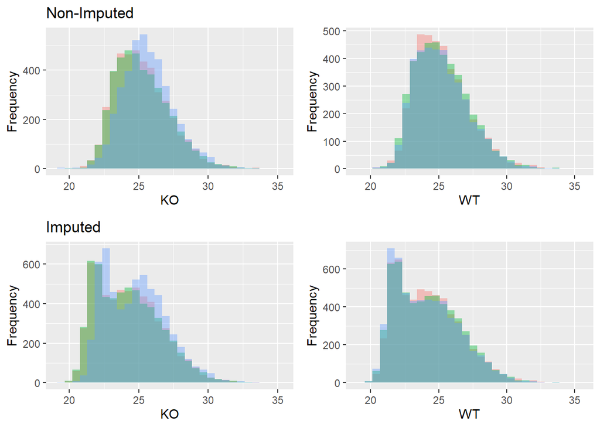

## Random Forest

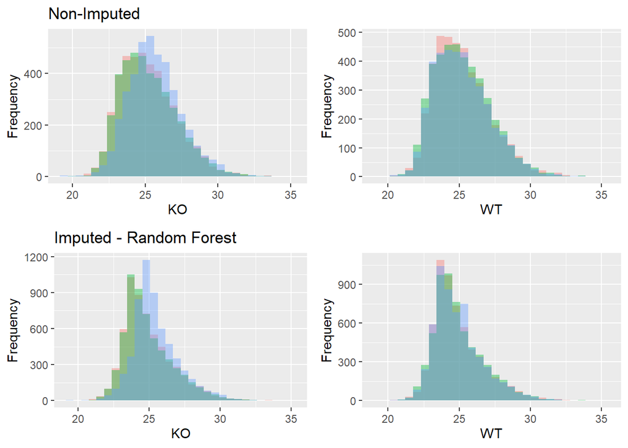

## k-Nearest Neighbors

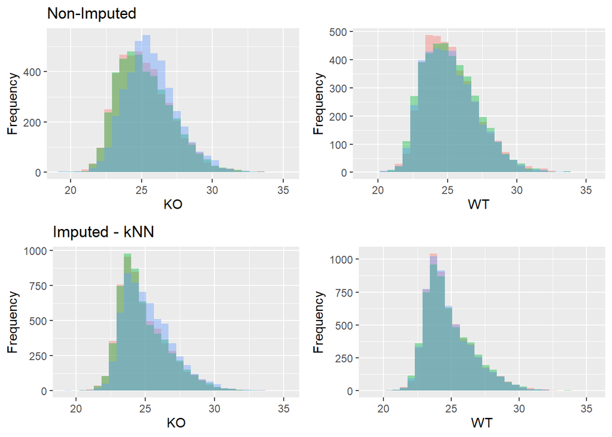

## Ludovic

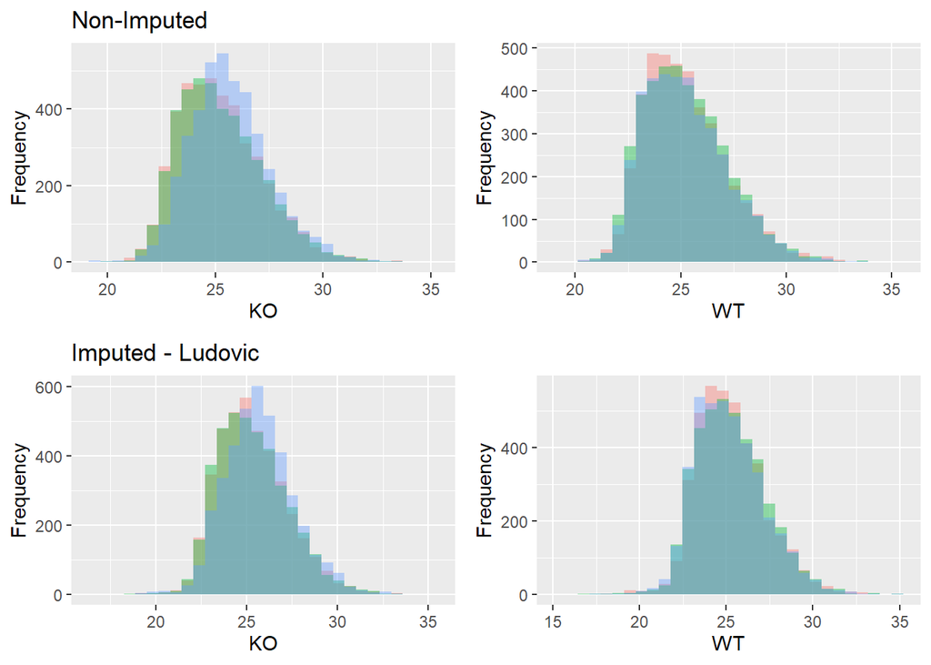

# Normalization

The 24th replicate of the KO cell type has the distribution shifted to the right and should be more similar to the other replicates. Therefore we tried several normalization methods to achieve this goal. We used the following methods:

1. Z-Score
2. Min-Max
3. Median Scaling
4. MAD (Median Absolute Deviation) Scaling
5. Linear Regression
6. VSN (Variance Stabilization Normalization)
7. EigenMS

## Z-Score

Z-score normalization standardizes data by subtracting the mean and dividing by the standard deviation. This technique transforms data into a distribution with a mean of 0 and a standard deviation of 1.

Formula: $\tilde{y}_{ij} = \frac{y_ij - \bar{y_j}}{\theta_j}$, where:

- $y_ij$ - value of the LFQ;
- $\bar{y_j}$ - mean of the LFQ values;
- $\theta_j$ - standard deviation of the LFQ values.

**Summary**  
The Z-SCORE method brought the distribution closer together, but we lost the original scale of the data and the differences are harder to see after normalization.

**DISTRIBUTIONS**

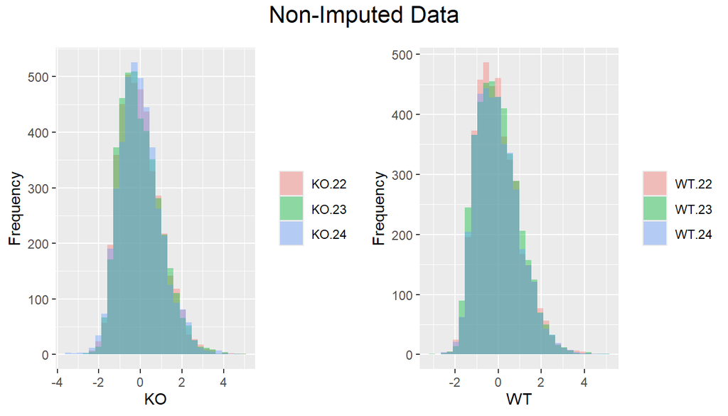

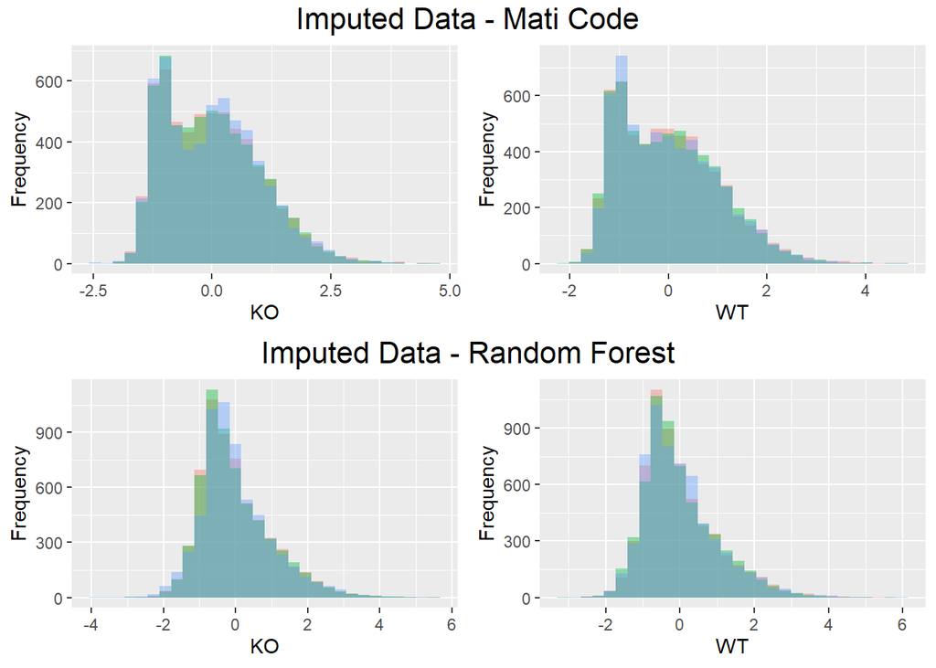

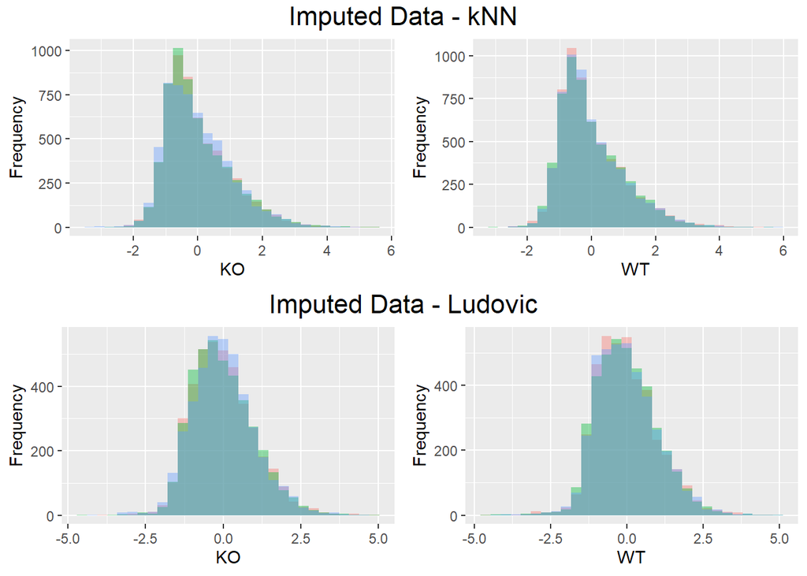

## Min-Max

Min-max normalization scales data to a specified range (usually [0, 1]) by subtracting the minimum value and dividing by the range of values.

**Summary**  
The MIN-MAX method didn’t succeed in bringing the distribution closer together. In conclusion, we probably shouldn’t use this method.

**DISTRIBUTIONS**

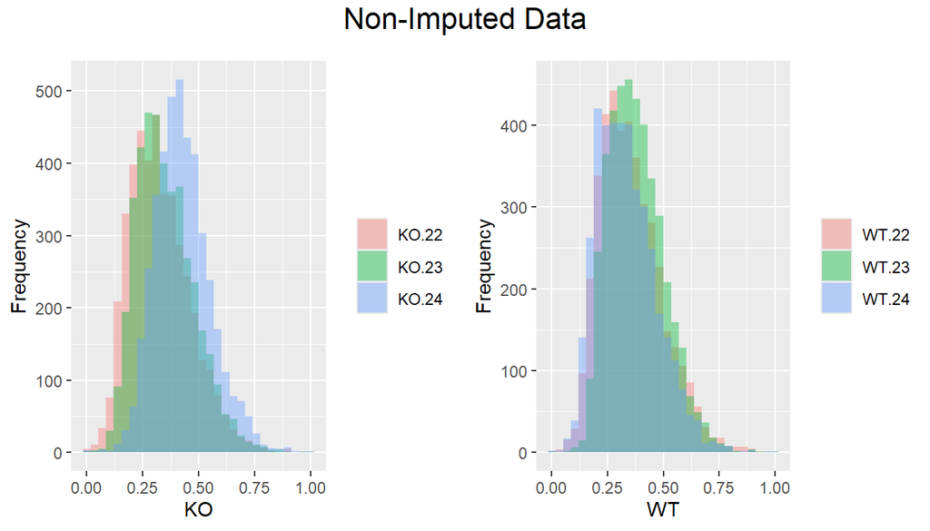

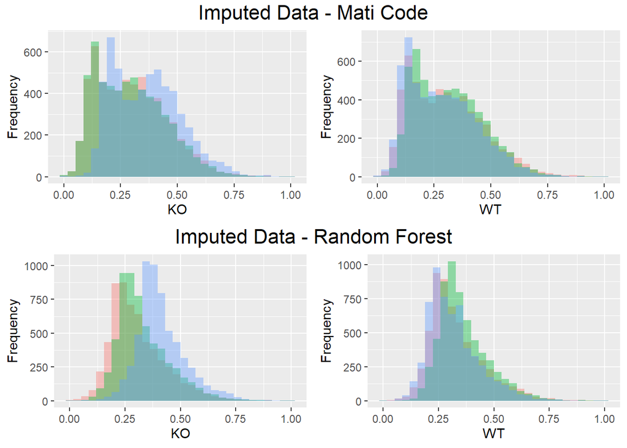

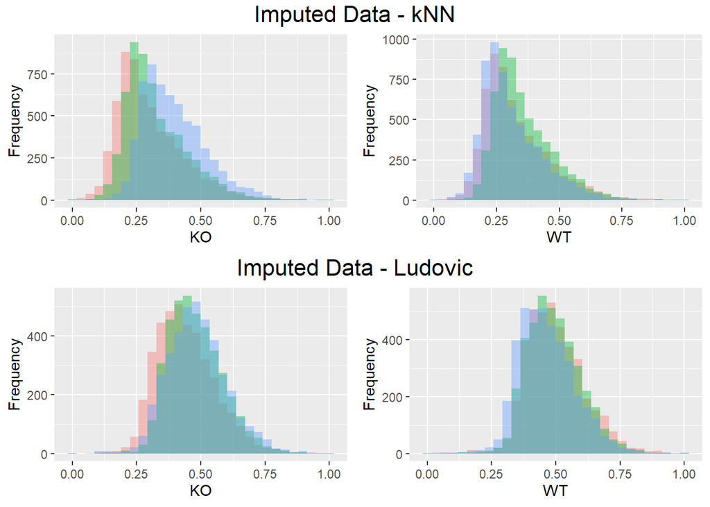

## Median Scaling

Median Scaling, also called the Robust Scalar, transforms x to x’ by subtracting each value of features by the median and dividing it by the interquartile range between the 1st quartile (25th quantile) and the 3rd quartile (75th quantile). The formula:

$$x' =
\frac{x-median(x)}{(Q3-Q1)}$$

**Summary**  
The MEDIAN scaling method brought the distributions closer together, but again we lost the original scale of the data and the differences are harder to see after normalization.

**DISTRIBUTIONS**

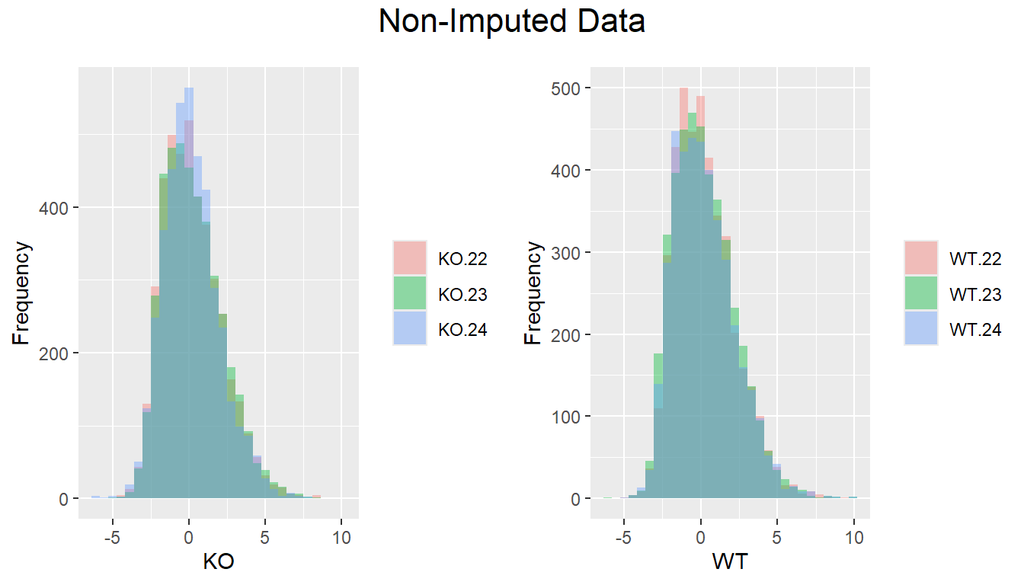

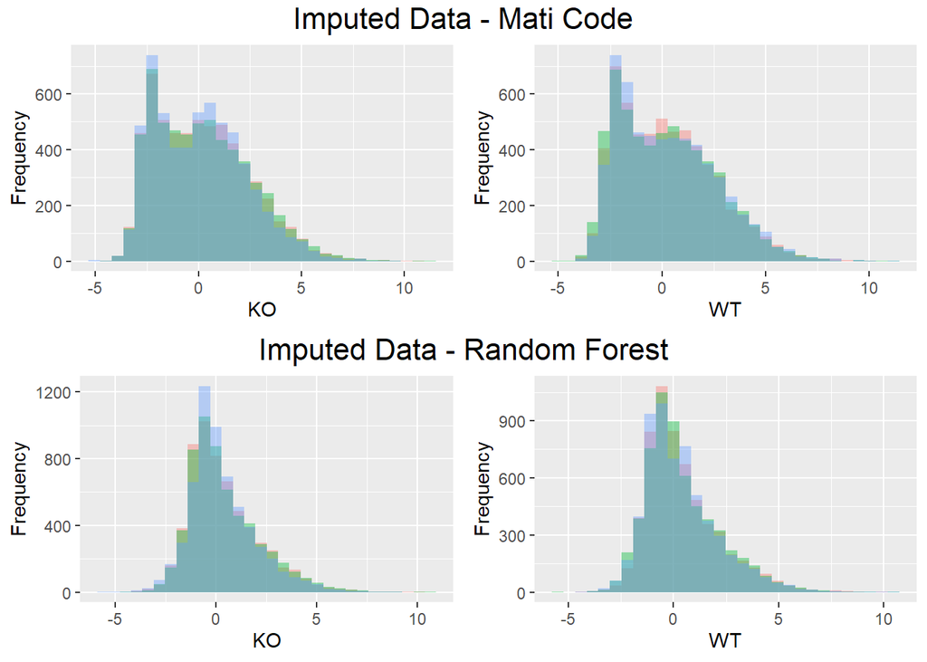

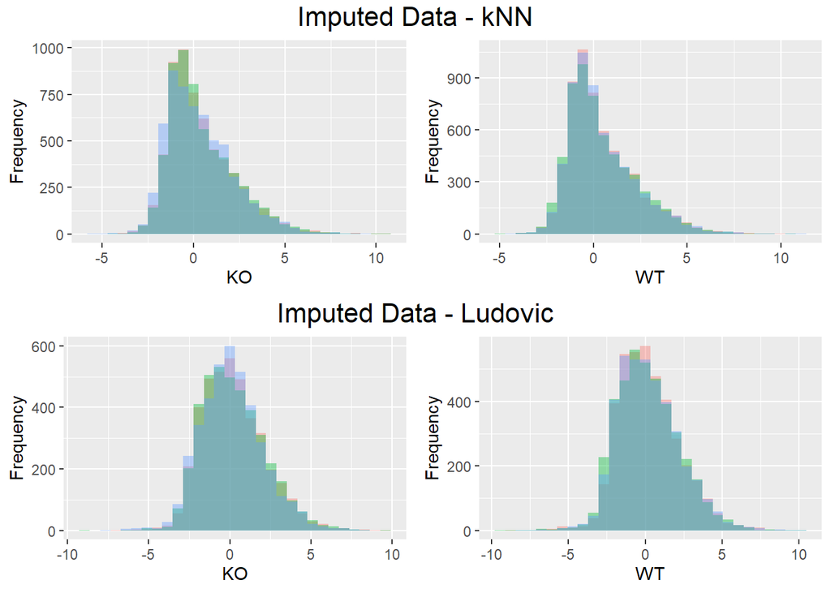

## MAD Scaling

MAD (**M**edian **A**bsoulte **D**eviation) Scaling transforms $x$ to $x'$ in similar way like Median Scaling, but it substractingthe MAD value from the $x$. The formula of MAD:

$$\tilde{X} = median(X) \\ MAD =
median\Big(|X_i - \tilde{X}|\Big)$$

and the formula of scaling is:

$$x' = \frac{x -
MAD}{(Q3-Q1)}$$

**Summary**  
The MAD scaling method brought the distributions closer together, but again we lost the original scale of the data and the differences are harder to see after normalization.

**DISTRIBUTIONS**

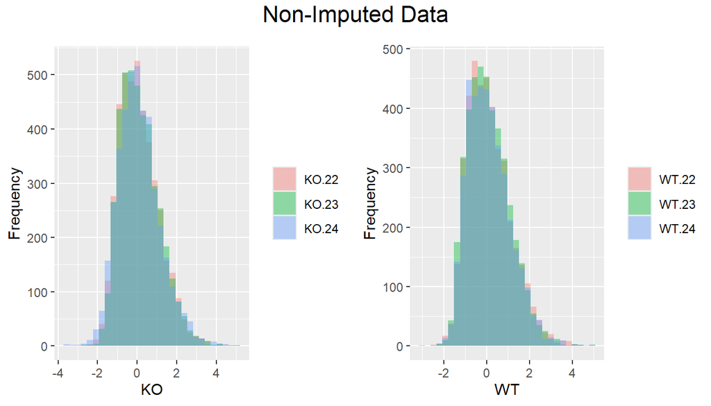

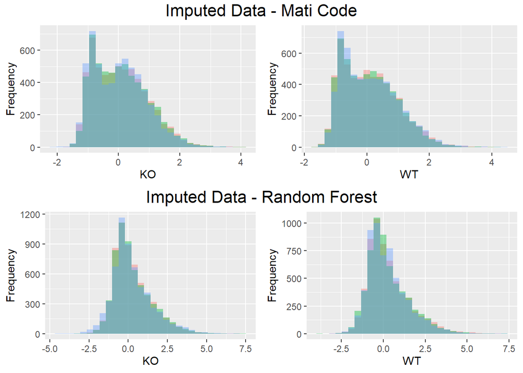

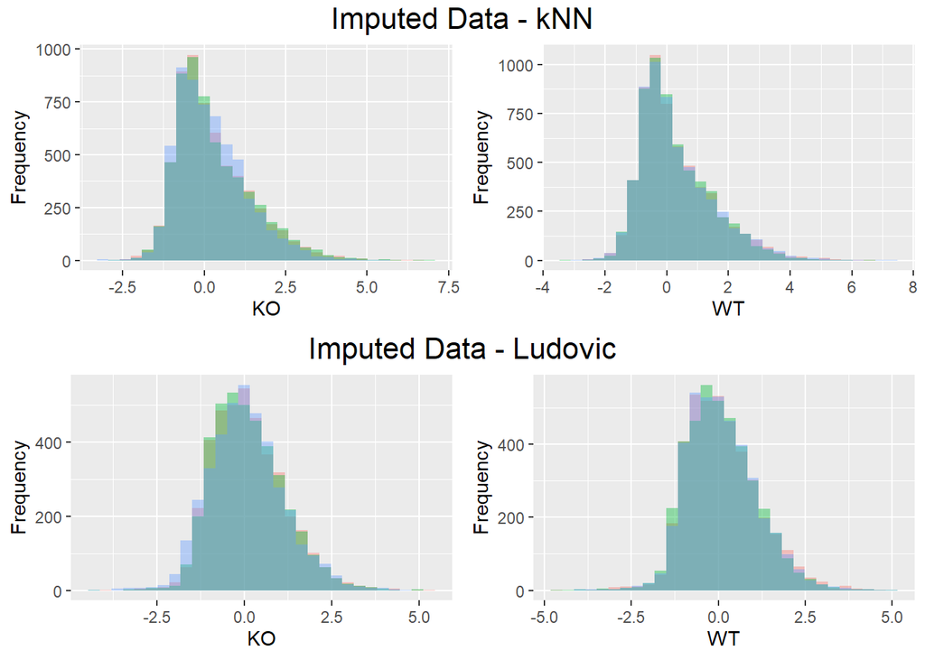

## Linear Regression

Normalization ny linear regression using a residual of the linear model $y = ax + b$ to normalize the data. In our project we have two variables: independent and dependent. The independent is **Batch** and the dependent is **LFQ**.

**Summary**  
The linear regression method brought the distributions closer together, but again we lost the original scale of the data and the differences are harder to see after normalization.

**DISTRIBUTIONS**

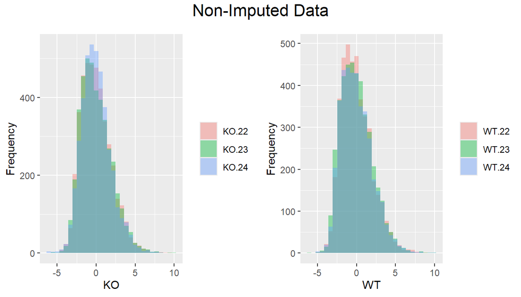

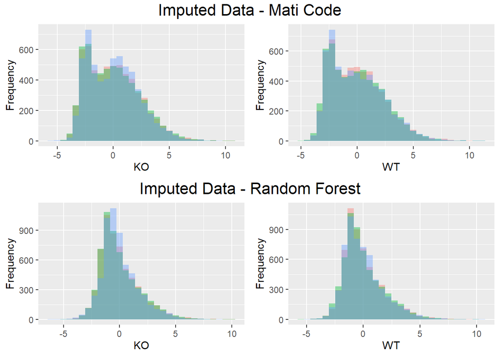

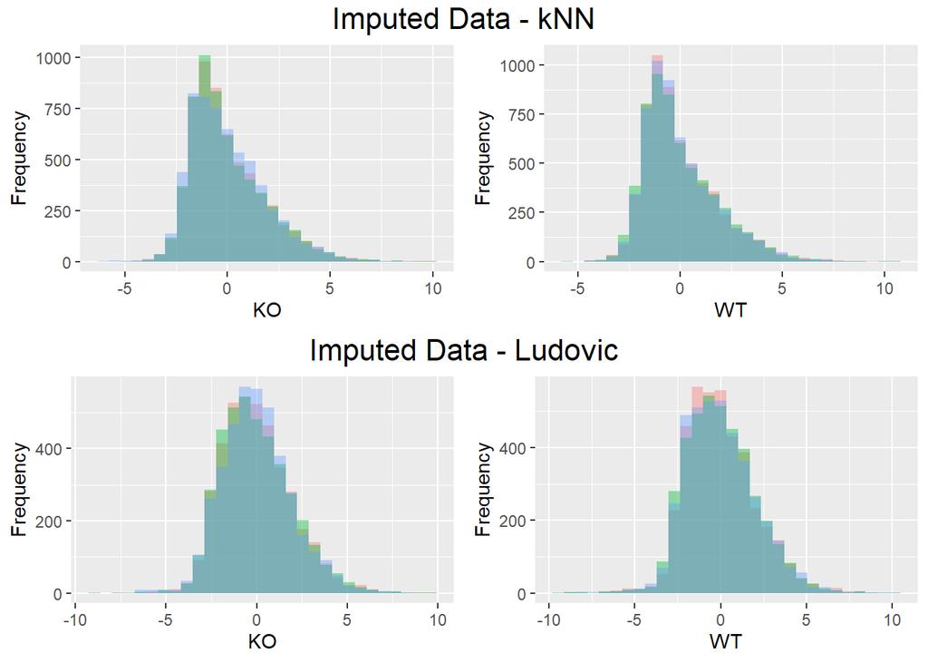

## VSN

VSN - **V**ariance **S**tabilization **N**ormalization

The data are returned on a $glog$ scale to base 2. More precisely, the transformed data are subject to the transformation $glog_2(f(b)*x+a)+c$, where the function $glog_2(u)=log_2(u+\sqrt{u*u+1}) = asinh(u)/log(2)$ is called the generalised logarithm, the offset $a$ and the scaling parameter $b$ are the fitted model parameters (see references), and $f(x)=exp(x)$ is a parameter transformation that allows ensuring positivity of the factor in front of x while using an unconstrained optimization over $b$ [[source](https://www.bioconductor.org/packages/devel/bioc/vignettes/vsn/inst/doc/C-likelihoodcomputations.pdf)]. The overall offset $c$ is computed from the $b$’s such that for large $x$ the transformation approximately corresponds to the $log_2$ function. This is done separately for each stratum, but with the same value across arrays. More precisely, if the element $b[s,i]$ of the array $b$ is the scaling parameter for the $s$-th stratum and the $i$-th array, then $c[s]$ is computed as $log2(2*f(mean(b[,i])))$. The offset $c$ is inconsequential for all differential expression calculations, but many users like to see the data in a range that they are familiar with.

**Summary**  
The VSN method brought the distributions closer together and we didn’t lose the original scale of the data. The method didn’t lose the differences between KO and WT cells at first glance. In addition, the 24th replicate of KO cell doesn’t stand out only in distribution of imputed data with kNN.

**DISTRIBUTIONS**

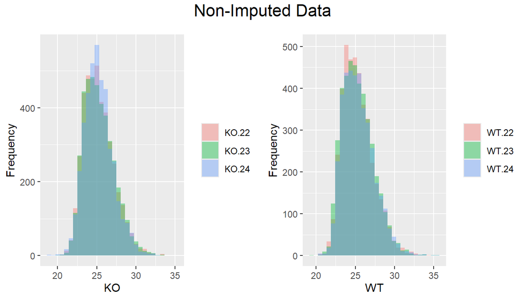

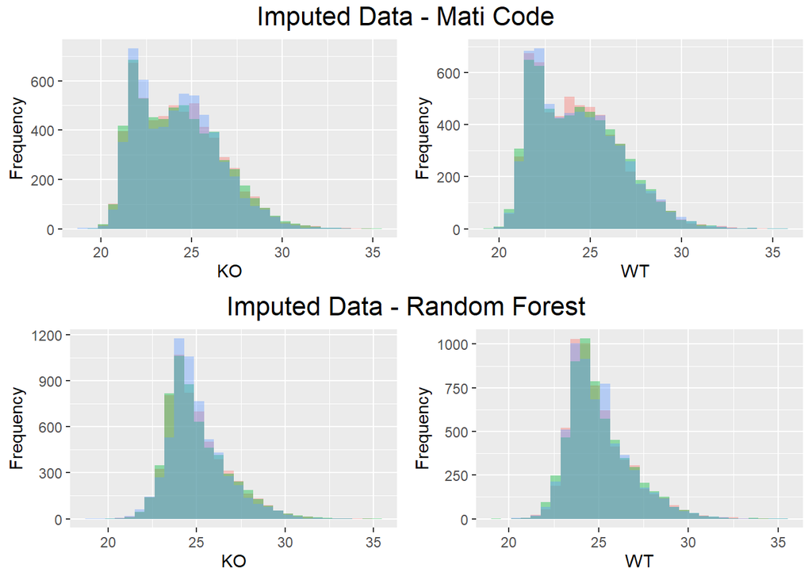

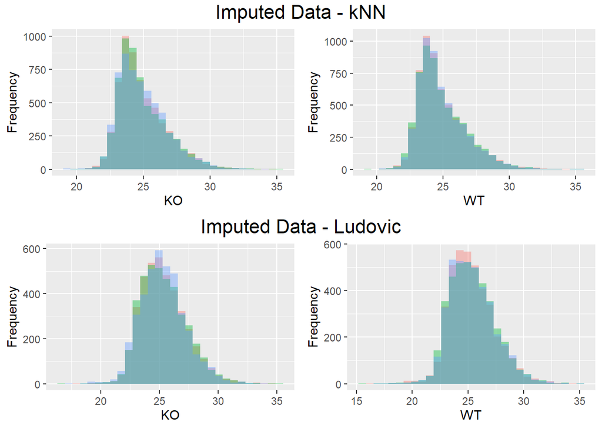

## EigenMS

EigenMS is a normalization method developed for high-throughput mass spectrometry (MS) proteomics data. It uses eigenvector-based adjustments to remove unwanted variation, such as batch effects, from the data. The method works by identifying systematic biases in the dataset and applying a correction while preserving biologically relevant signals.

In the EigenMS method, eigentrends are calculated by decomposing the systematic variation in the proteomics data matrix using Singular Value Decomposition (SVD). This is typically expressed as:

$$X = U \Sigma V'$$
Where:

- $X$ represents the original data matrix.
- $U$ and $v'$ are orthogonal matrices.
- $\Sigma$ is a diagonal matrix of singular values.

The decomposition isolates systematic trends (eigentrends) as columns in $U$, which can then be removed to adjust for unwanted variation.

**Summary**  
The EigenMS method was the one which kept the differences between the replicates and cell types (KO and WT). The distribution are close together and we solve the problem of 24th replicate. In my opinion the EigenMS method gives the best results.

**DISTRIBUTIONS**

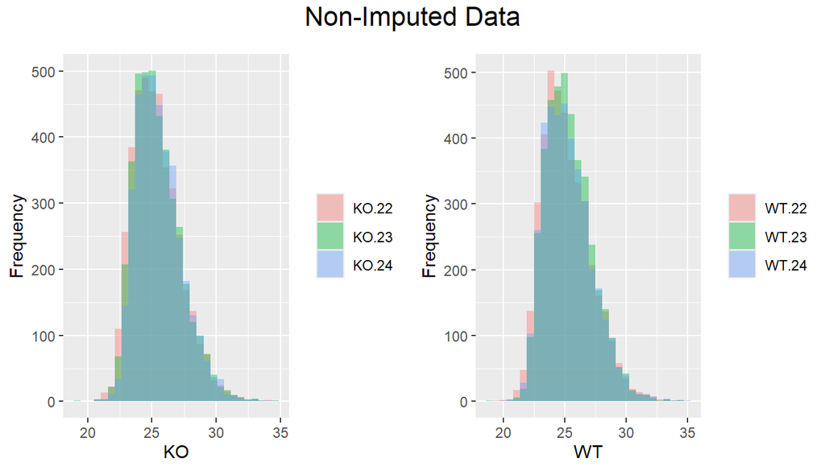

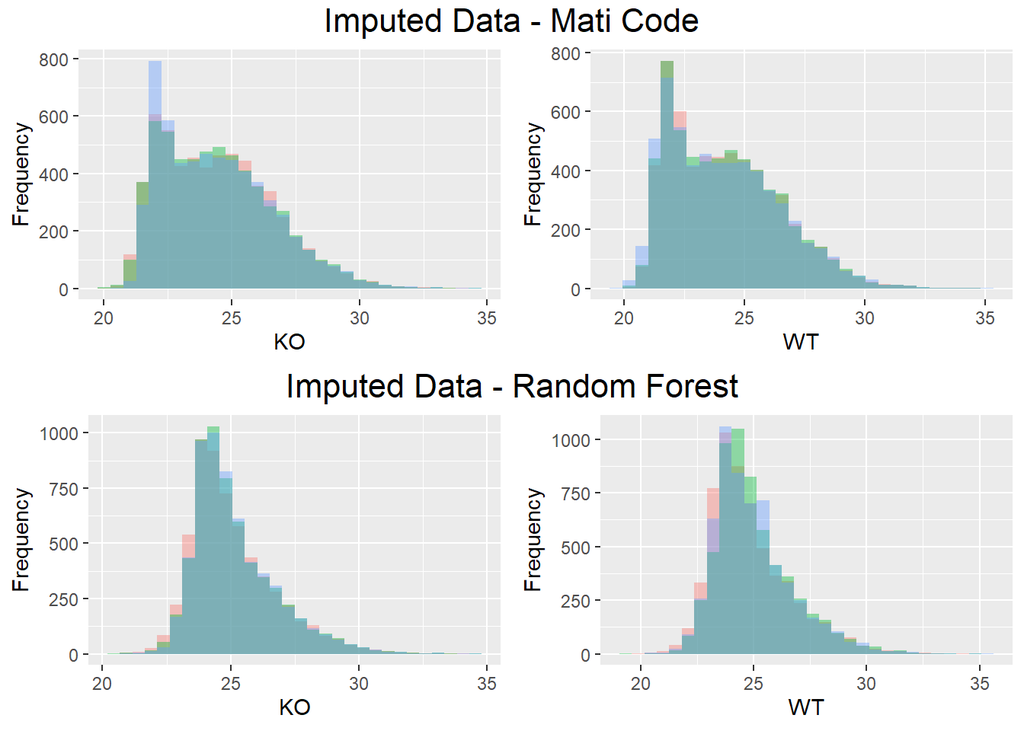

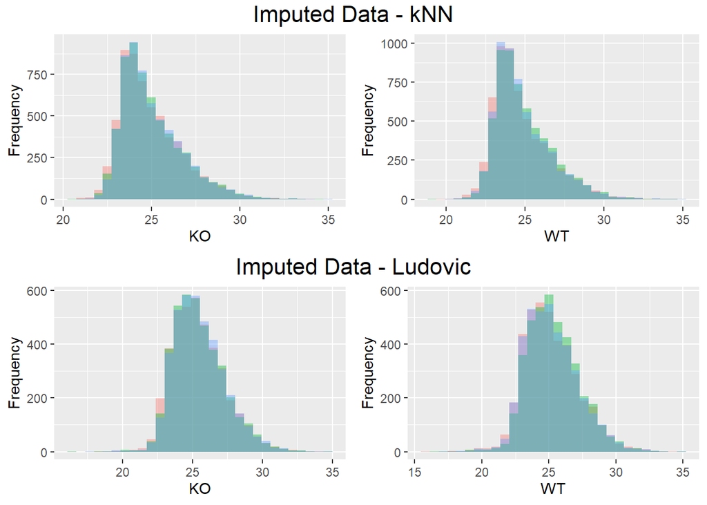

# Statistics Metrics

## CV

**COEFFICIENT OF VARIATION (CV) / RELATIVE STANDARD DEVIATION (RSD)**

This is a way to measure how spread out values are in a dataset relative to the mean. A lower RSD/CV indicates better normalization. It is calculated as:

$CV = \frac{\sigma}{\mu}$

where:

- $\sigma$: The standard deviation of dataset
- $\mu$: The mean of dataset

When we take a closer look at the violin plots, we can see the strange pattern in the results for the **kNN** imputation method. Namely, many values have a CV close to the 0, which can mean that the standard deviation of the values is also close to the 0, which means that the values are very similar, which shouldn’t be the case.

The violin plots for the other methods look better and show the distribution/density of the CV correctly.

### Non-Imputed

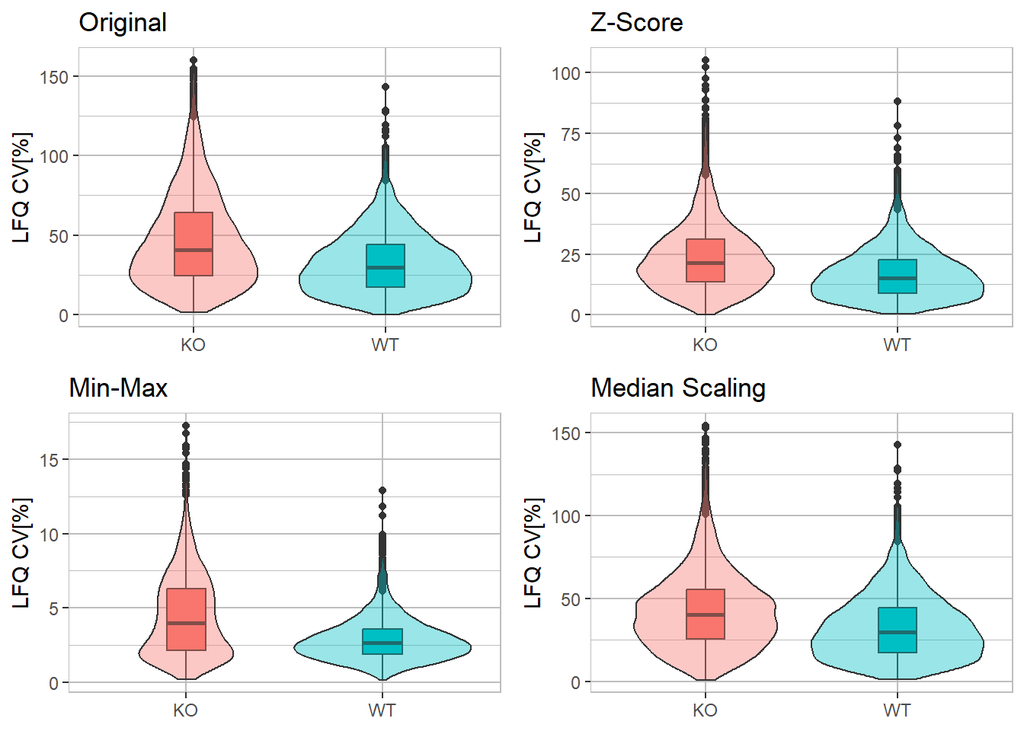

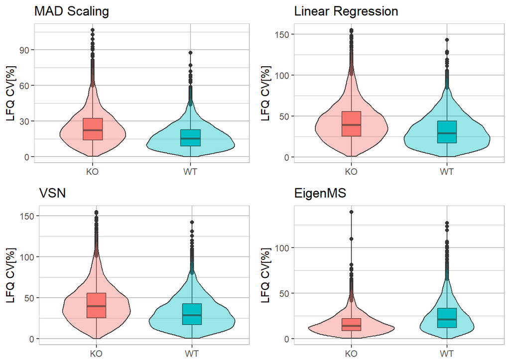

### Mati Code

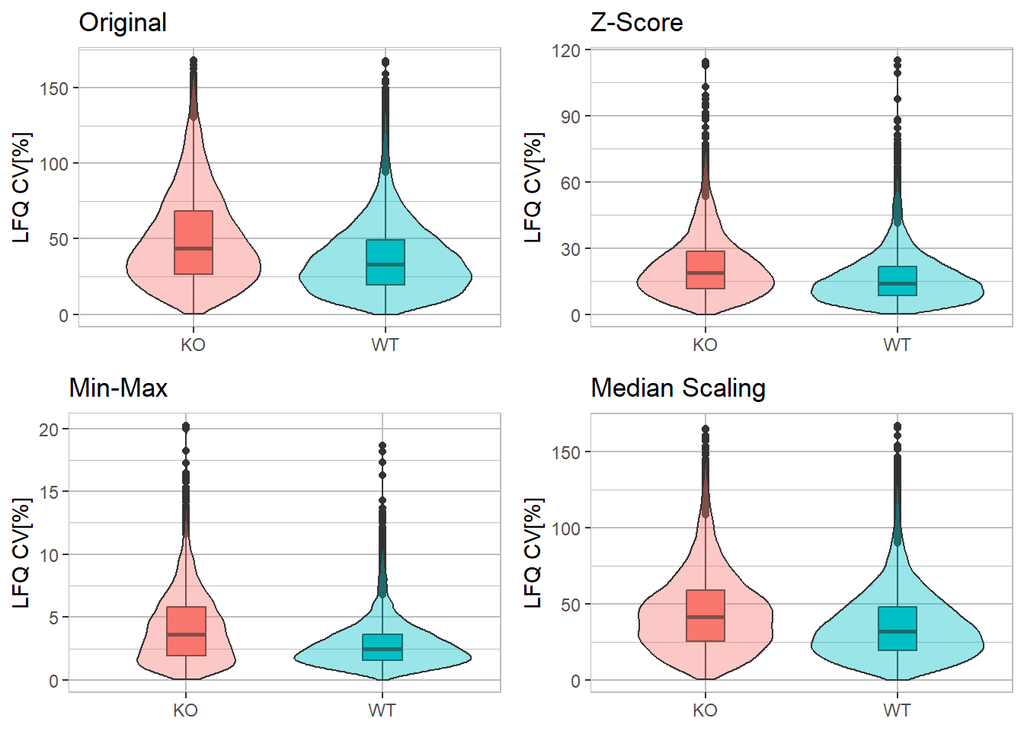

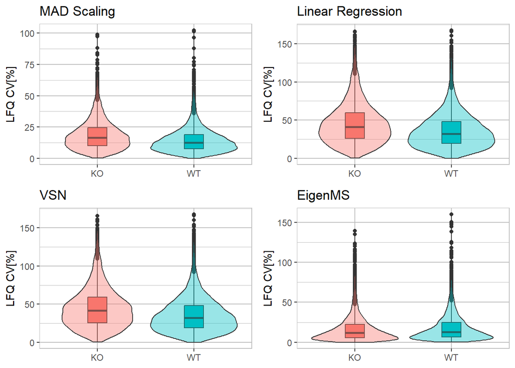

### Random Forest

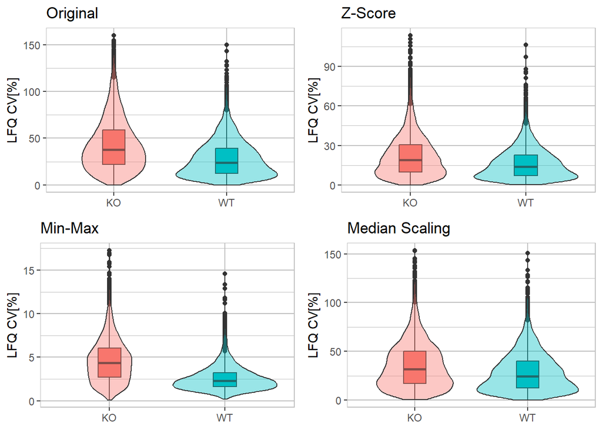

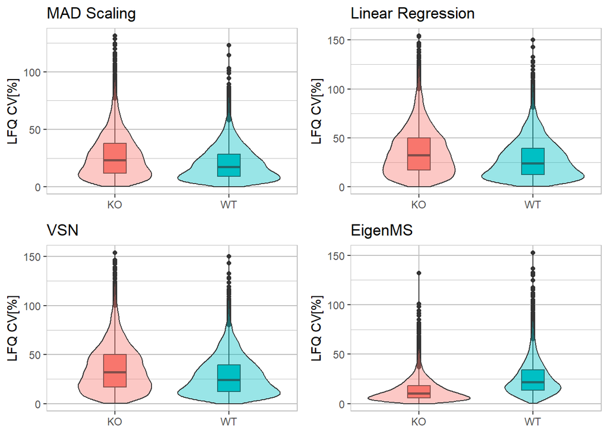